# Practice3_data_visualization

Daniel Kumazawa Morais

09-03-2026

## Data visualization using ggplot2

### We will work with the data of fishing vessels (tonnage and fishing hours per country)

```r
library(tidyverse)
```

#### We will load the dataset from the Github repository and we will tidy it following the instructions from Session 1

```r
url <- "https://raw.githubusercontent.com/bioinfo-arctic/FSK2053/main/Spring_2024/data/GFW-fishing-vessels-v2.csv"
dat_vessels <- read_csv(url)
```

Now, with the data loaded, we will select the variables we want to keep and stored it in a wide table format

```r
wide_data_vessels <- dat_vessels %>%
  select(mmsi,flag_gfw,vessel_class_gfw,tonnage_gt_gfw,paste0("fishing_hours_",2012:2020))
wide_data_vessels
```

```
## # A tibble: 114,191 × 13
##         mmsi flag_gfw vessel_class_gfw   tonnage_gt_gfw fishing_hours_2012
##        <dbl> <chr>    <chr>                       <dbl>              <dbl>
##  1  40120000 GRC      trawlers                    133                   NA
##  2 444002410 KOR      tuna_purse_seines          2132.                  NA
##  3 987654320 PHL      tuna_purse_seines          1081                   NA
##  4 554128120 NRU      tuna_purse_seines          1350                   NA
##  5 112119600 USA      fishing                      85.5                 NA
##  6  70100732 ARG      fishing                     729                   NA
##  7  24106140 ESP      purse_seines                 58                   NA
##  8 124072890 ESP      trawlers                     79.5                 NA
##  9 420948738 IND      drifting_longlines          465                   NA
## 10 503526000 AUS      set_longlines              2561                   NA
## # ℹ 114,181 more rows
## # ℹ 8 more variables: fishing_hours_2013 <dbl>, fishing_hours_2014 <dbl>,
## #   fishing_hours_2015 <dbl>, fishing_hours_2016 <dbl>,
## #   fishing_hours_2017 <dbl>, fishing_hours_2018 <dbl>,
## #   fishing_hours_2019 <dbl>, fishing_hours_2020 <dbl>
```

We are going to add the continent information, using the country code from variable *flag_gfw* We can do this with the countrycode library.

```r
#install.packages("countrycode") # in case you don't have it ;)
library(countrycode)
wide_data_vessels <- wide_data_vessels %>% mutate(continent = countrycode(wide_data_vessels$flag_gfw, origin="iso3c",destination="continent"))
names(wide_data_vessels)
```

```
##  [1] "mmsi"               "flag_gfw"           "vessel_class_gfw"
##  [4] "tonnage_gt_gfw"     "fishing_hours_2012" "fishing_hours_2013"
##  [7] "fishing_hours_2014" "fishing_hours_2015" "fishing_hours_2016"
## [10] "fishing_hours_2017" "fishing_hours_2018" "fishing_hours_2019"
## [13] "fishing_hours_2020" "continent"
```

We will now, tidy up the table, and will remove all observations with *NA*

```r
tidy_data_vessels <- wide_data_vessels %>%
  pivot_longer(names_to = "year",values_to = "fishing_hours", paste0("fishing_hours_",2012:2020)) %>%
  mutate(year = gsub("fishing_hours_","",year)) %>%
  drop_na()
tidy_data_vessels
```

```
## # A tibble: 429,005 × 7
##      mmsi flag_gfw vessel_class_gfw tonnage_gt_gfw continent year  fishing_hours
##     <dbl> <chr>    <chr>                     <dbl> <chr>     <chr>         <dbl>
##  1 4.01e7 GRC      trawlers                  133   Europe    2020          674.
##  2 4.44e8 KOR      tuna_purse_sein…         2132.  Asia      2020          144.
##  3 9.88e8 PHL      tuna_purse_sein…         1081   Asia      2020          545.
##  4 5.54e8 NRU      tuna_purse_sein…         1350   Oceania   2020          587.
##  5 1.12e8 USA      fishing                    85.5 Americas  2020          318.
##  6 7.01e7 ARG      fishing                   729   Americas  2014          304.
##  7 2.41e7 ESP      purse_seines               58   Europe    2020          132.
##  8 1.24e8 ESP      trawlers                   79.5 Europe    2020           62.4
##  9 4.21e8 IND      drifting_longli…          465   Asia      2013          321.
## 10 5.04e8 AUS      set_longlines            2561   Oceania   2020           26.4
## # ℹ 428,995 more rows
```

### Counts of total vessels per country

We want to explore the data on how many vessels are included in the dataset for each country. We will use the continent as a factor to compare differences among countries.

We could use `count()` on the tidy data table

```r
vessel_count_tidy <- tidy_data_vessels %>% group_by(continent, flag_gfw) %>% count()
```

However, if we use the long (tidy) dataset, there can be several lines for each ship. Then, we have to use the wide dataset, since it has a row for every vessel.

```r
vessel_count <- wide_data_vessels %>% group_by(continent, flag_gfw) %>% count()
vessel_count
```

```
## # A tibble: 167 × 3
## # Groups:   continent, flag_gfw [167]
##    continent flag_gfw     n
##    <chr>     <chr>    <int>
##  1 Africa    AGO         37
##  2 Africa    CIV          4
##  3 Africa    CMR         23
##  4 Africa    COM         14
##  5 Africa    CPV          7
##  6 Africa    DJI          4
##  7 Africa    DZA         10
##  8 Africa    EGY          2
##  9 Africa    GHA         99
## 10 Africa    GIN          6
## # ℹ 157 more rows
```

To be sure that the identifiers of the vessels are unique, using `distinct()` on the wide dataset

```r
unique_ships <- wide_data_vessels %>% select(mmsi) %>% distinct()
```

The number of rows is the same than the original. So all vessel **mmsi** values are unique.

A more detailed way of checking it.

```r
wide_data_vessels %>%
  group_by(mmsi) %>%
  summarise(n = n()) %>%
  summary(n)
```

```
##       mmsi                 n
##  Min.   :1.280e+02   Min.   :1
##  1st Qu.:3.160e+08   1st Qu.:1
##  Median :4.124e+08   Median :1
##  Mean   :4.212e+08   Mean   :1
##  3rd Qu.:4.151e+08   3rd Qu.:1
##  Max.   :1.057e+09   Max.   :1
```

### Plots with a single numeric variable and a categorical factor

Here, we are going to produce our first ggplot:

#### `geom_point()` (one numeric variable vs a categorical factor)

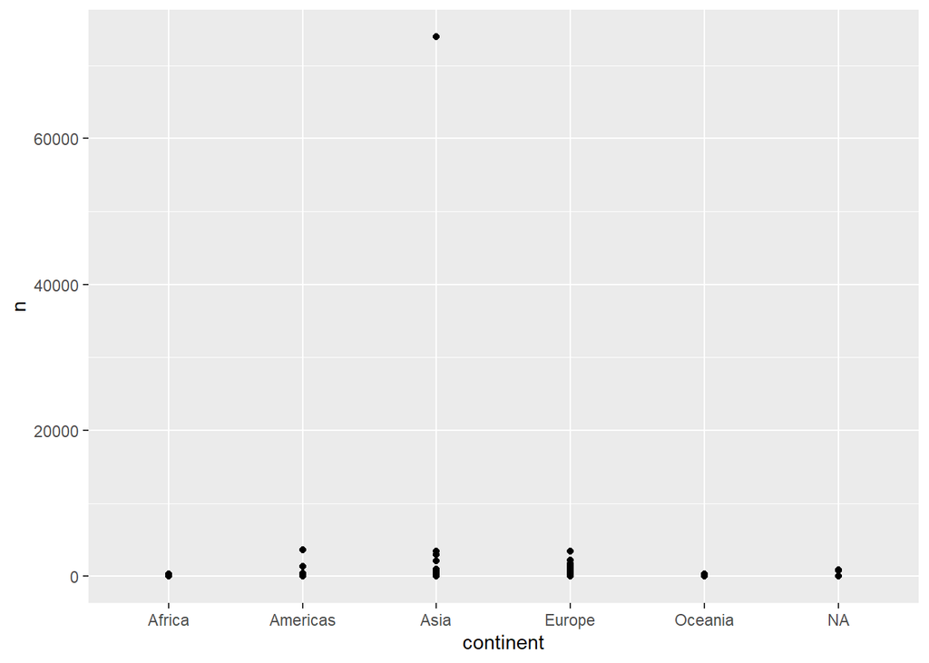

```r
vessel_count %>%
  ggplot(aes(x=continent,y=n)) +
  geom_point()
```

There is one country that has many more vessels than the others (possibly China). We can filter it out

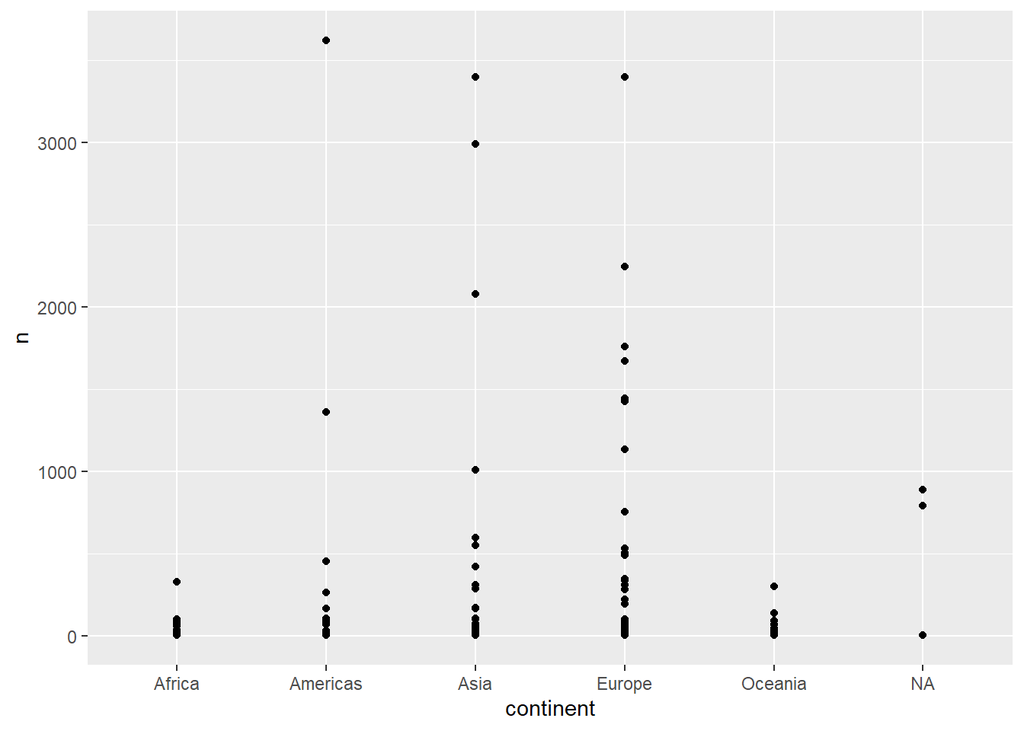

```r
vessel_count_no_china <- vessel_count %>% filter(n != max(vessel_count$n))

vessel_count_no_china %>%
  ggplot(aes(x=continent,y=n)) +
  geom_point()
```

This looks better!

We can improve the visualization using `geom_jitter()` and *alpha* colours:

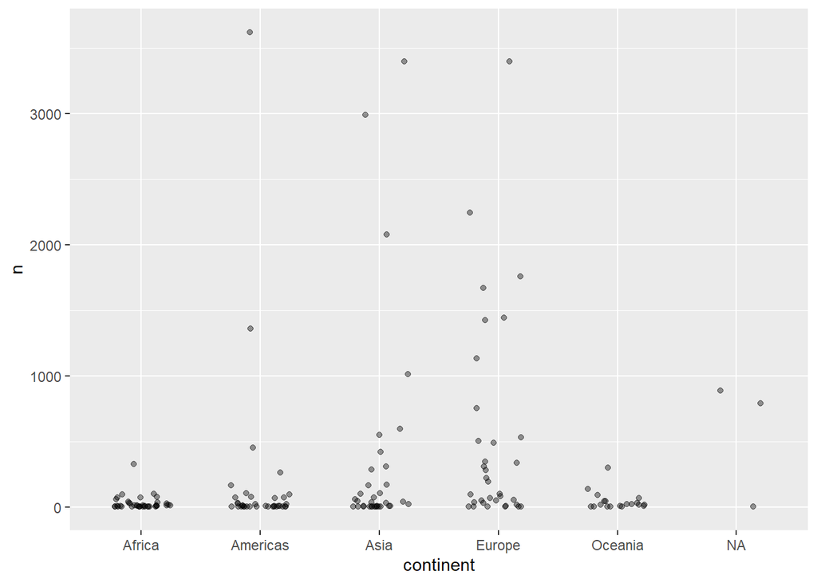

```r
vessel_count_no_china %>%
  ggplot(aes(x=continent,y=n)) +
  geom_jitter(width = 0.25, alpha = 0.4)
```

And we can add some colour.

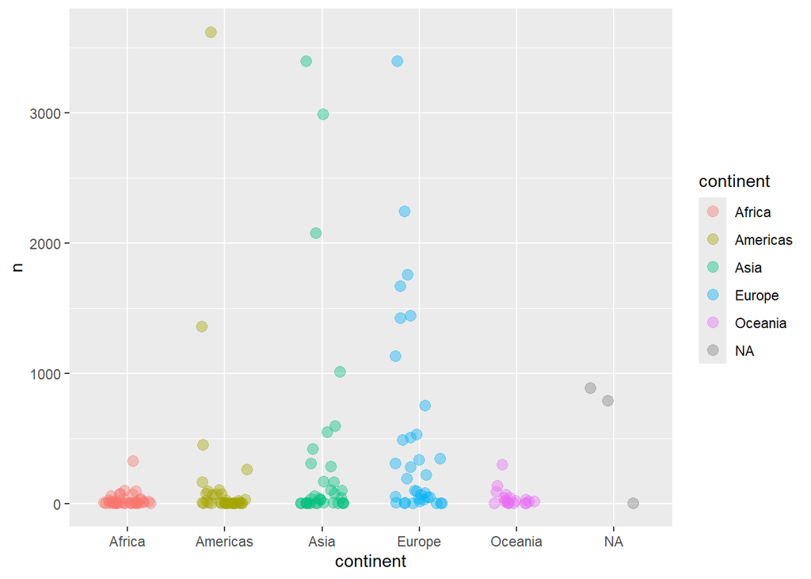

```r
vessel_count_no_china %>%
  ggplot(aes(x=continent,y=n, color=continent)) +
  geom_jitter(width = 0.25, alpha = 0.4, size = 3)
```

We can select boxplot geometry:

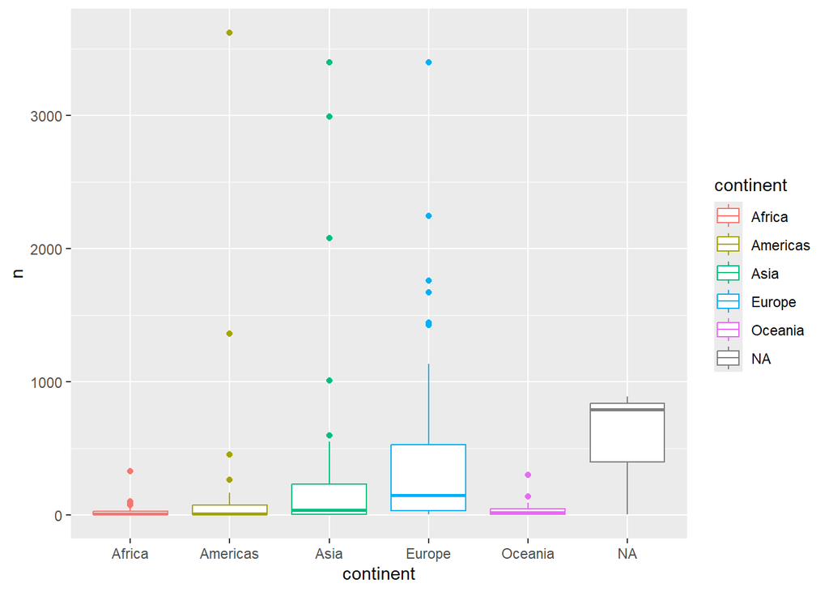

```r
vessel_count_no_china %>%
  ggplot(aes(x=continent,y=n, color=continent)) +
  geom_boxplot()
```

Compare to this:

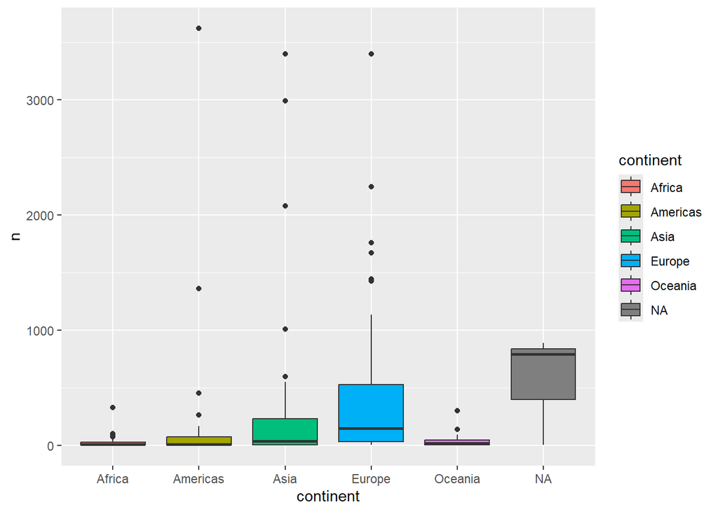

```r
vessel_count_no_china %>%
  ggplot(aes(x=continent,y=n)) +
  geom_boxplot(aes(fill=continent))
```

Or we can use violin plots:

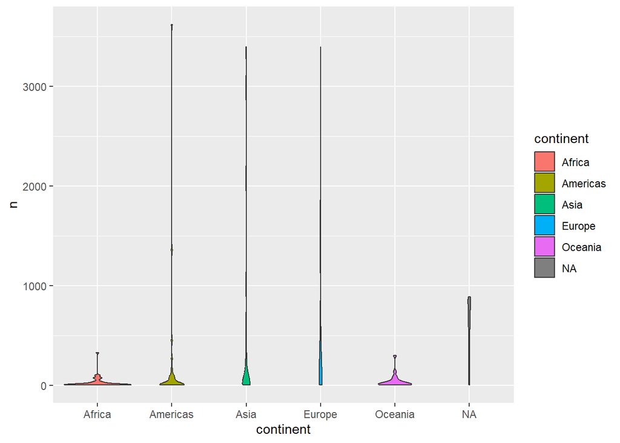

```r
vessel_count_no_china  %>%
  ggplot(aes(x=continent,y=n)) +
  geom_violin(aes(fill=continent))
```

Perhaps it is a good idea to transform the y axis to log (log10)

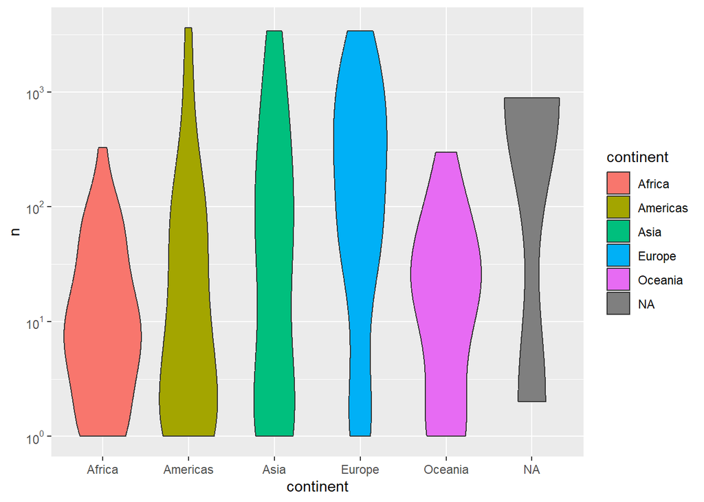

```r
vessel_count_no_china  %>%
  ggplot(aes(x=continent,y=n)) +
  geom_violin(aes(fill=continent)) +
  scale_y_log10(
    breaks = scales::trans_breaks("log10", function(x) 10^x),
    labels = scales::trans_format("log10", scales::math_format(10^.x)))
```

Learn more about using `scales()` here: https://r4ds.had.co.nz/graphics-for-communication.html?q=scale#scales https://rpubs.com/techanswers88/remove-scientific-notation-in-ggplot

Now, we can bring China data back:

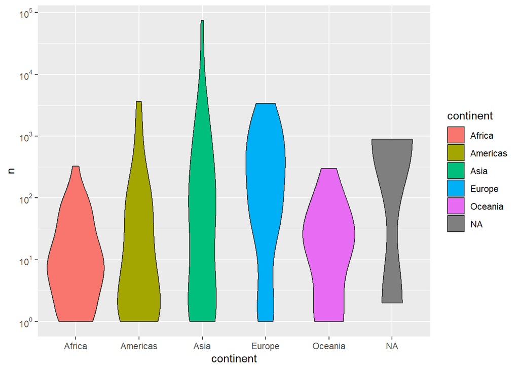

```r
vessel_count  %>%
  ggplot(aes(x=continent,y=n)) +
  geom_violin(aes(fill=continent)) +
  scale_y_log10(
    breaks = scales::trans_breaks("log10", function(x) 10^x),
    labels = scales::trans_format("log10", scales::math_format(10^.x)))
```

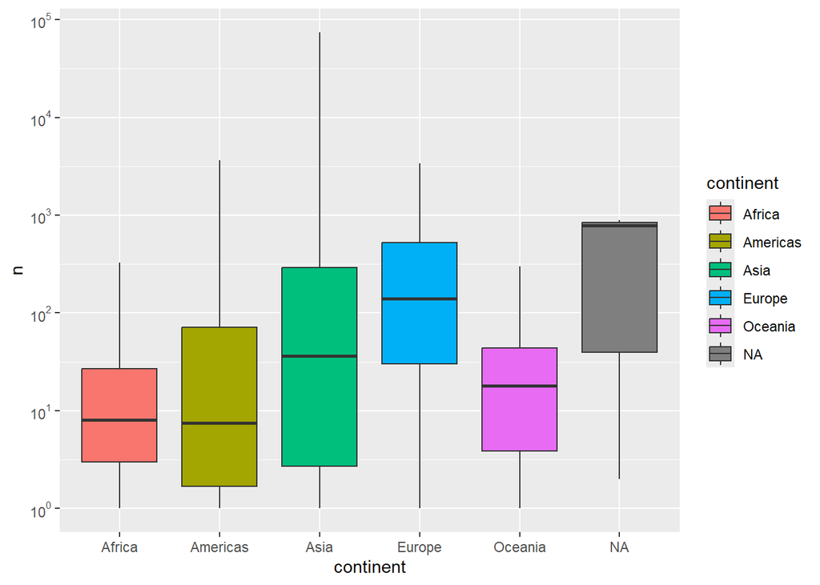

```r
vessel_count  %>%
  ggplot(aes(x=continent,y=n)) +
  geom_boxplot(aes(fill=continent)) +
  scale_y_log10(
    breaks = scales::trans_breaks("log10", function(x) 10^x),
    labels = scales::trans_format("log10", scales::math_format(10^.x)))
```

#### Adding two layers of geometries to the same plot

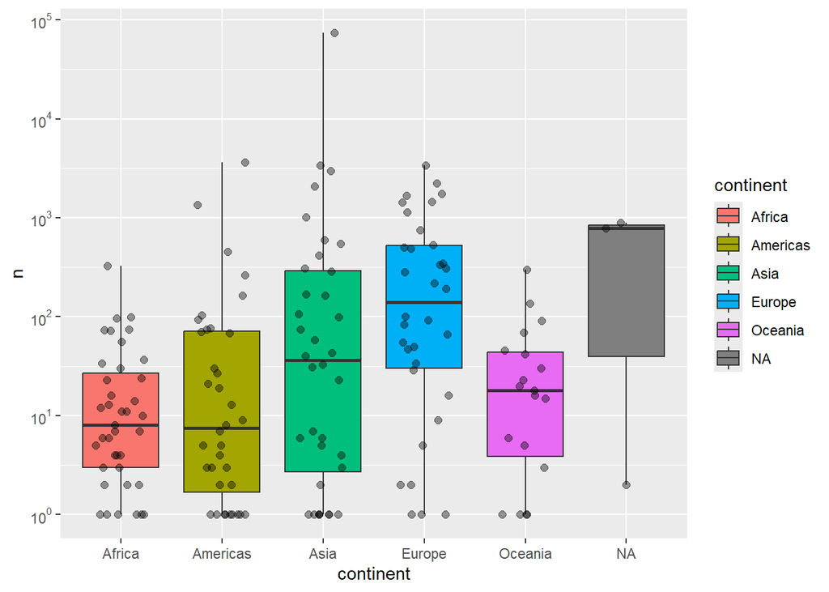

```r
vessel_count  %>%
  ggplot(aes(x=continent,y=n)) +
  geom_boxplot(aes(fill=continent)) +
  geom_jitter(width = 0.25, alpha = 0.4, size = 2) +
    scale_y_log10(
    breaks = scales::trans_breaks("log10", function(x) 10^x),
    labels = scales::trans_format("log10", scales::math_format(10^.x)))
```

Let’s reorder the x-axis by the median value:

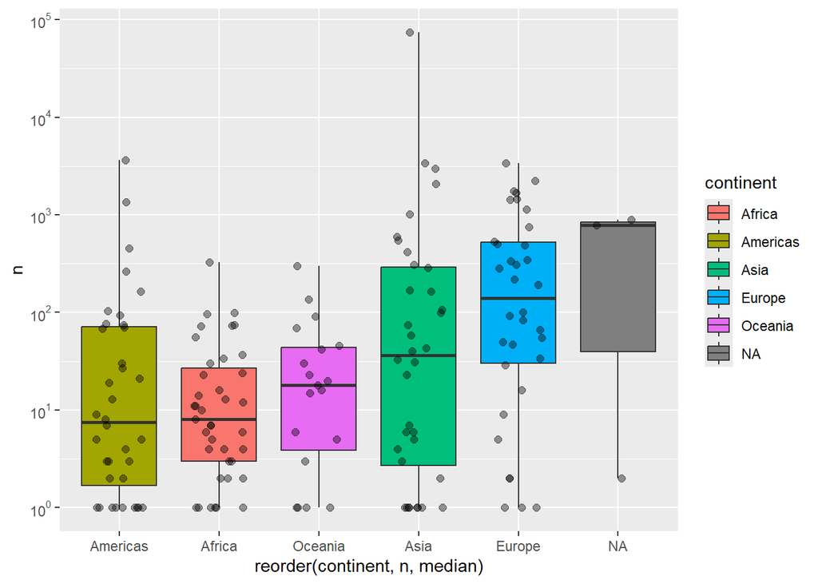

```r
vessel_count  %>%
  ggplot(aes(x=reorder(continent,n,median),y=n)) +
  geom_boxplot(aes(fill=continent)) +
  geom_jitter(width = 0.25, alpha = 0.4, size = 2) +
  scale_y_log10(
    breaks = scales::trans_breaks("log10", function(x) 10^x),
    labels = scales::trans_format("log10", scales::math_format(10^.x)))
```

### Barplots

#### Barplots are useful to represent a summarizing variable for each group of the data.

We want to generate a barplot of the total number of vessels per country included in our data set for every continent.

We will produce a barplot of the total number of vessels per continent:

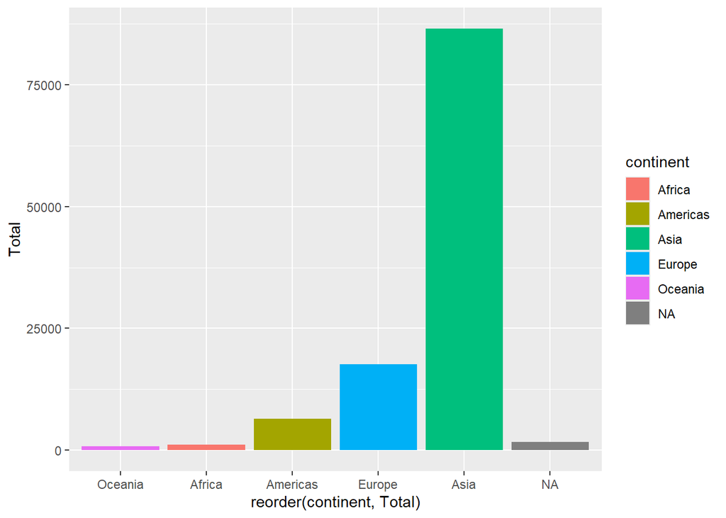

```r
vessel_count %>% group_by(continent) %>% summarise(Total=sum(n)) %>%
  ggplot(aes(x=reorder(continent,Total),y=Total)) +
  geom_bar(stat="identity",aes(fill=continent))
```

If we want horizontal bars, labels and log scale in the axis:

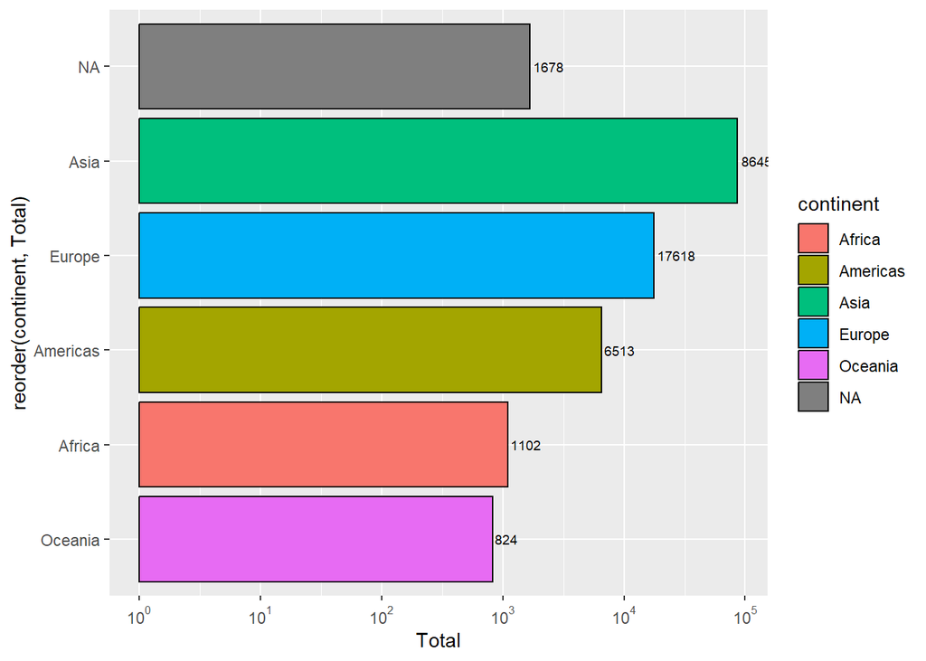

```r
vessel_count %>% group_by(continent) %>% summarise(Total=sum(n)) %>%
  ggplot(aes(x=reorder(continent,Total),y=Total)) +
  geom_bar(stat="identity",aes(fill=continent),color="black") +
  coord_flip() +
  geom_text(aes(label=Total), hjust=-0.1, size=2.5) +
  scale_y_log10(
  breaks = scales::trans_breaks("log10", function(x) 10^x),
  labels = scales::trans_format("log10", scales::math_format(10^.x)))
```

If we want to add the error bars, we have to calculate the sd in the summarise function

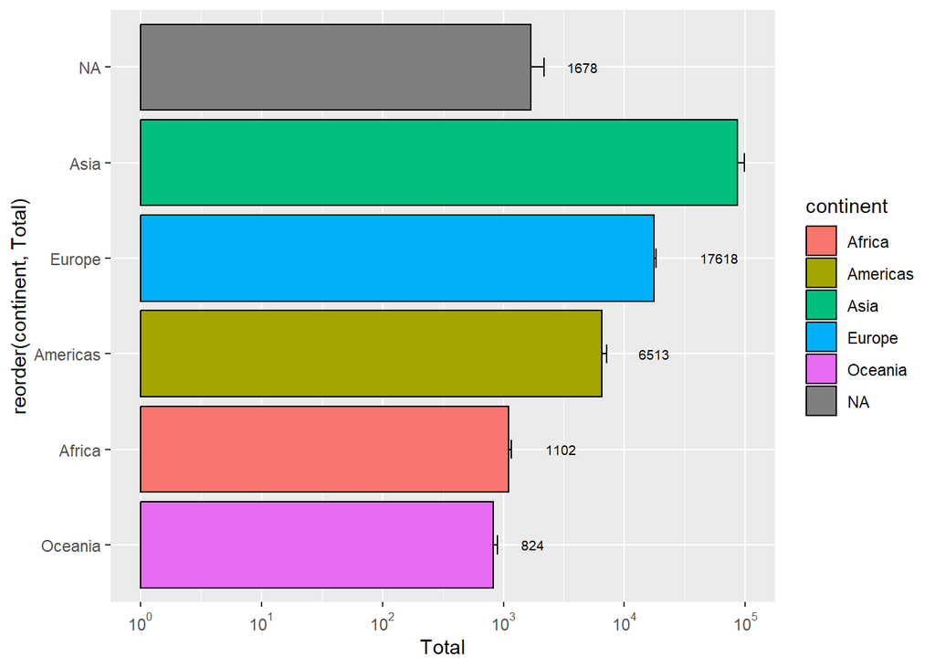

```r
vessel_count %>% group_by(continent) %>% summarise(Total=sum(n), sd=sd(n)) %>%
  ggplot(aes(x=reorder(continent,Total),y=Total)) +
  geom_bar(stat="identity",aes(fill=continent),color="black") +
  coord_flip() +
  geom_text(aes(label=Total), hjust=-1.2, size=2.5) +
  scale_y_log10(
    breaks = scales::trans_breaks("log10", function(x) 10^x),
    labels = scales::trans_format("log10", scales::math_format(10^.x))) +
    geom_errorbar(aes(ymin=Total, ymax=Total+sd), width=.2)
```

### Plots with one numerical variable and an ordered factor

### Line plots

We will group by continent and will summarise the total sum of fishing hours. Let’s plot the total hours by year, to see the temporal trend by continent: *For that, we need to will return to the tidy dataset.

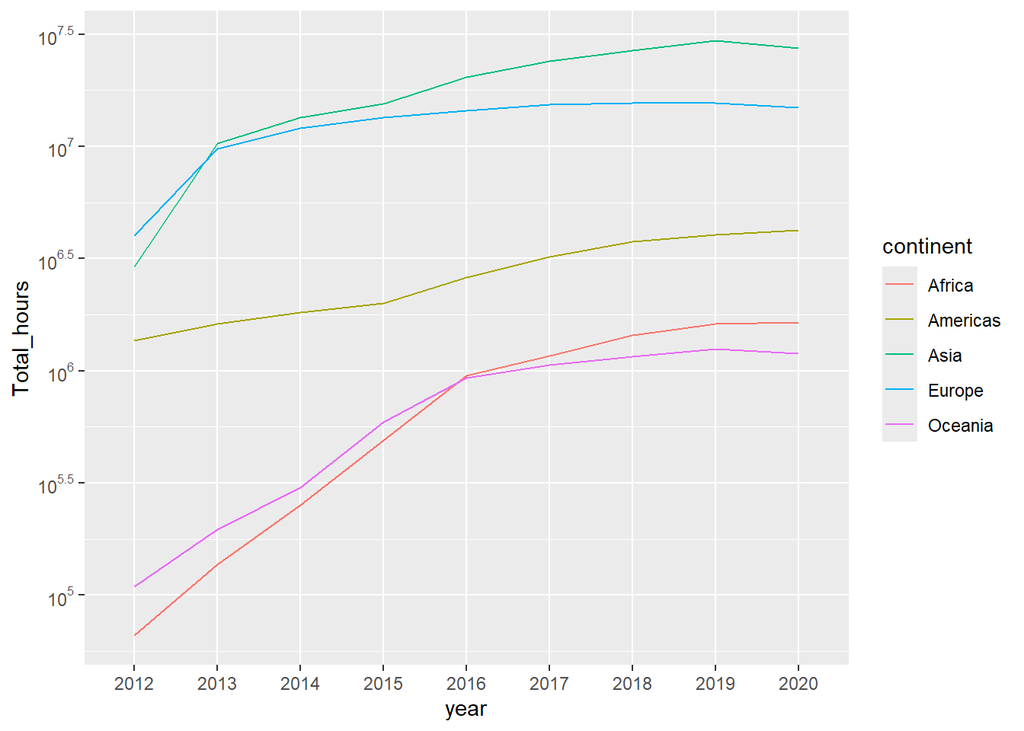

```r
tidy_data_vessels %>% group_by(continent, year) %>%
  summarise(Total_hours=sum(fishing_hours),sd=sd(fishing_hours),count=n()) %>%
  ggplot(aes(x=year,y=Total_hours)) +
  geom_line(aes(color=continent,group=continent))+
  scale_y_log10(
  breaks = scales::trans_breaks("log10", function(x) 10^x),
  labels = scales::trans_format("log10", scales::math_format(10^.x)))
```

### Plots with two numerical variables

### Scatter plot

We can calculate the total tonnage and the total fishing hours for each country and we will represent this in a scatterplot: As usual, we need to log-transform due to the values of China.

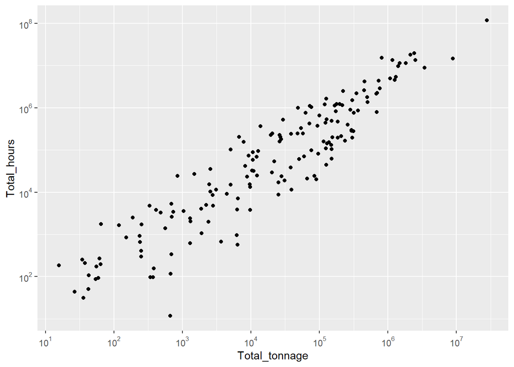

```r
tidy_data_vessels %>% group_by(continent, flag_gfw) %>%
  summarise(Total_hours=sum(fishing_hours),Total_tonnage=sum(tonnage_gt_gfw),count=n()) %>%
  ggplot(aes(x=Total_tonnage,y=Total_hours)) +
  geom_point() +
  scale_y_log10(
    breaks = scales::trans_breaks("log10", function(x) 10^x),
    labels = scales::trans_format("log10", scales::math_format(10^.x))) +
  scale_x_log10(
    breaks = scales::trans_breaks("log10", function(x) 10^x),
    labels = scales::trans_format("log10", scales::math_format(10^.x)))
```

Add colours by continent.

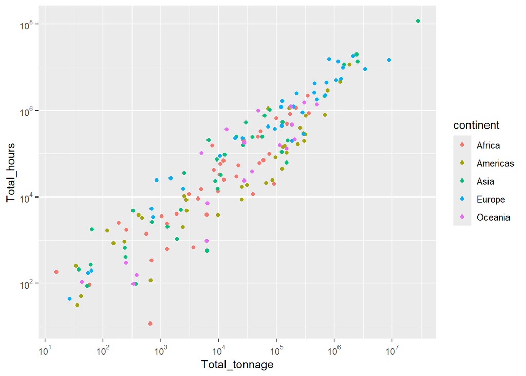

```r
tidy_data_vessels %>% group_by(continent, flag_gfw) %>%
  summarise(Total_hours=sum(fishing_hours),Total_tonnage=sum(tonnage_gt_gfw),count=n()) %>%
  ggplot(aes(x=Total_tonnage,y=Total_hours)) +
  geom_point(aes(color=continent)) +
  scale_y_log10(
    breaks = scales::trans_breaks("log10", function(x) 10^x),
    labels = scales::trans_format("log10", scales::math_format(10^.x))) +
  scale_x_log10(
    breaks = scales::trans_breaks("log10", function(x) 10^x),
    labels = scales::trans_format("log10", scales::math_format(10^.x)))
```

### Facet_wrap

We will draw several panels depending on the values of a categorical variable. Here the categorical variable is continent.

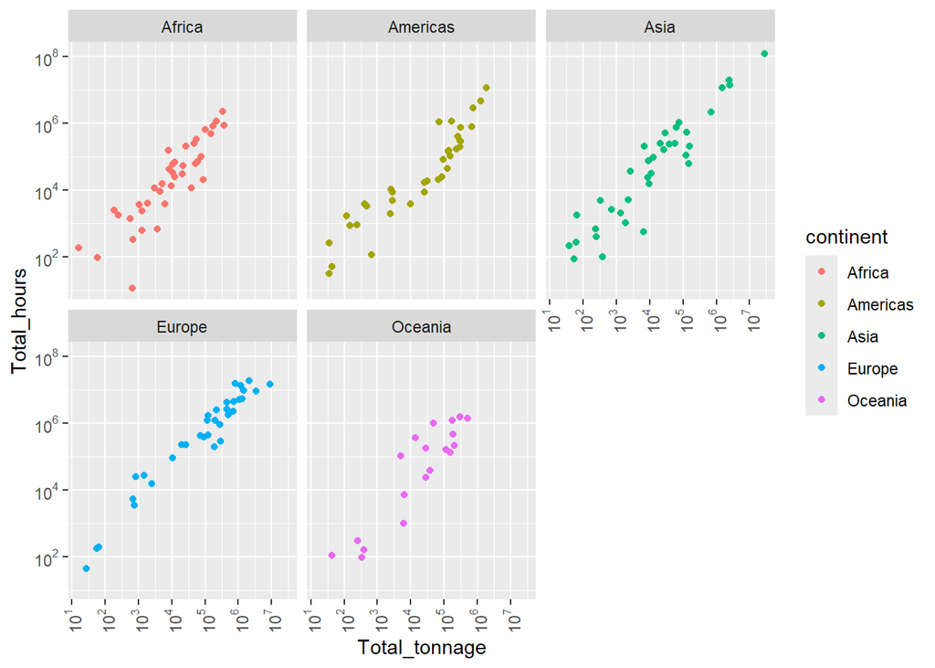

```r
tidy_data_vessels %>% group_by(continent, flag_gfw) %>%
  summarise(Total_hours=sum(fishing_hours),Total_tonnage=sum(tonnage_gt_gfw),count=n()) %>%
  ggplot(aes(x=Total_tonnage,y=Total_hours)) +
  geom_point(aes(color=continent)) +
  scale_y_log10(
    breaks = scales::trans_breaks("log10", function(x) 10^x),
    labels = scales::trans_format("log10", scales::math_format(10^.x))) +
  scale_x_log10(
    breaks = scales::trans_breaks("log10", function(x) 10^x),
    labels = scales::trans_format("log10", scales::math_format(10^.x))) +
  theme(axis.text.x = element_text(angle = 90, vjust = 0.5, hjust=1)) +
  facet_wrap(~ continent)
```

Add can a trend line (from a linear model):

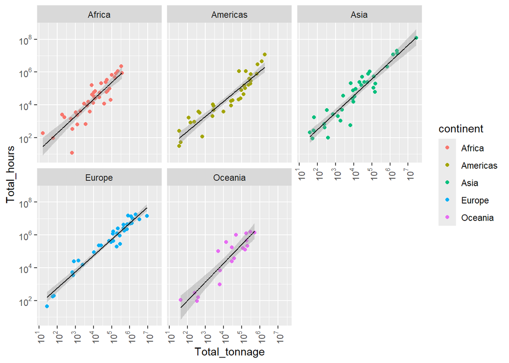

```r
tidy_data_vessels %>% group_by(continent, flag_gfw) %>%
  summarise(Total_hours=sum(fishing_hours),Total_tonnage=sum(tonnage_gt_gfw),count=n()) %>%
  ggplot(aes(x=Total_tonnage,y=Total_hours)) +
  geom_point(aes(color=continent)) +
  scale_y_log10(
    breaks = scales::trans_breaks("log10", function(x) 10^x),
    labels = scales::trans_format("log10", scales::math_format(10^.x))) +
  scale_x_log10(
    breaks = scales::trans_breaks("log10", function(x) 10^x),
    labels = scales::trans_format("log10", scales::math_format(10^.x))) +
  facet_wrap(~ continent) +
  theme(axis.text.x = element_text(angle = 90, vjust = 0.5, hjust=1)) +
  geom_smooth(formula = y ~ x, method="lm",color="black", linewidth=0.5)
```

### Distribution of a quantitative variable

#### Histograms and density plots

Now we want to explore how the fishing time per vessel is distributed for the different continents:

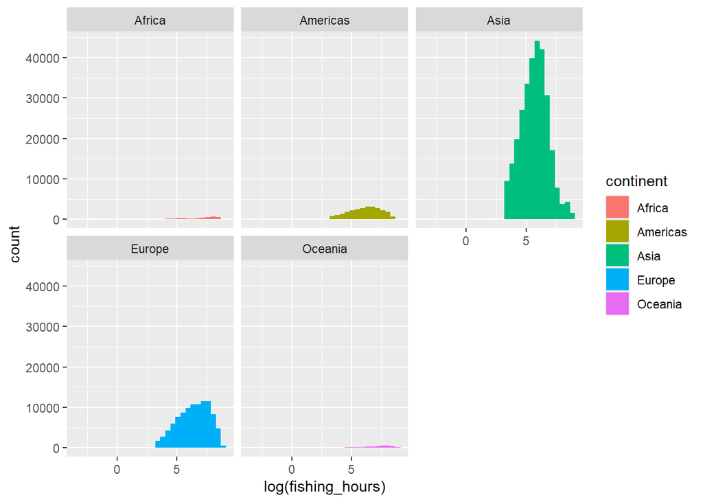

```r
tidy_data_vessels  %>%
ggplot(aes(x=log(fishing_hours))) +
  geom_histogram(aes(group=continent,fill=continent))+
  facet_wrap(~ continent)
```

We can read more about grouping in aesthetics here: https://ggplot2.tidyverse.org/reference/aes_group_order.html

The counts are very different for each continent. We would like to have independent scale in Y:

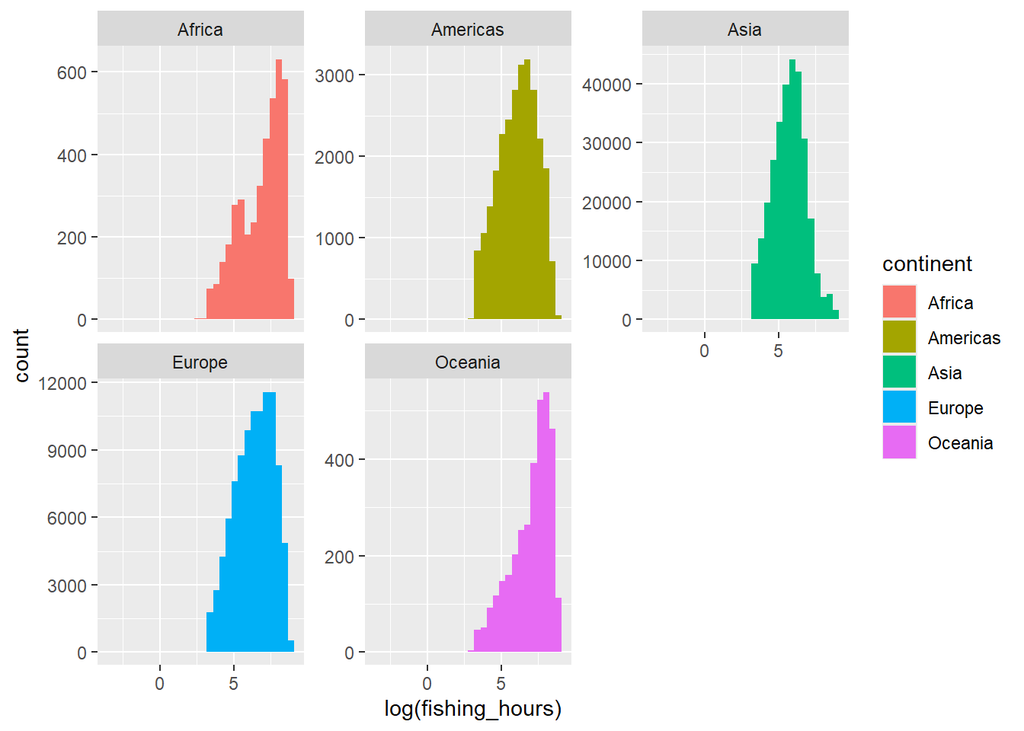

```r
tidy_data_vessels  %>%
  ggplot(aes(x=log(fishing_hours))) +
  geom_histogram(aes(group=continent,fill=continent))+
  facet_wrap(~ continent,scales = "free_y")
```

We can smooth the curves using `geom_density()`

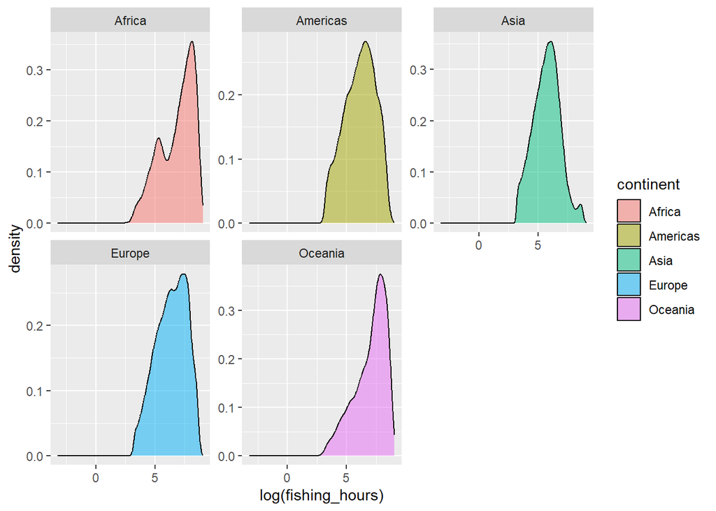

```r
tidy_data_vessels  %>%
  ggplot(aes(x=log(fishing_hours))) +
  geom_density(aes(group=continent, fill=continent), alpha=.5)+
  facet_wrap(~ continent,scales = "free_y")
```

And now we can explore the change over the years:

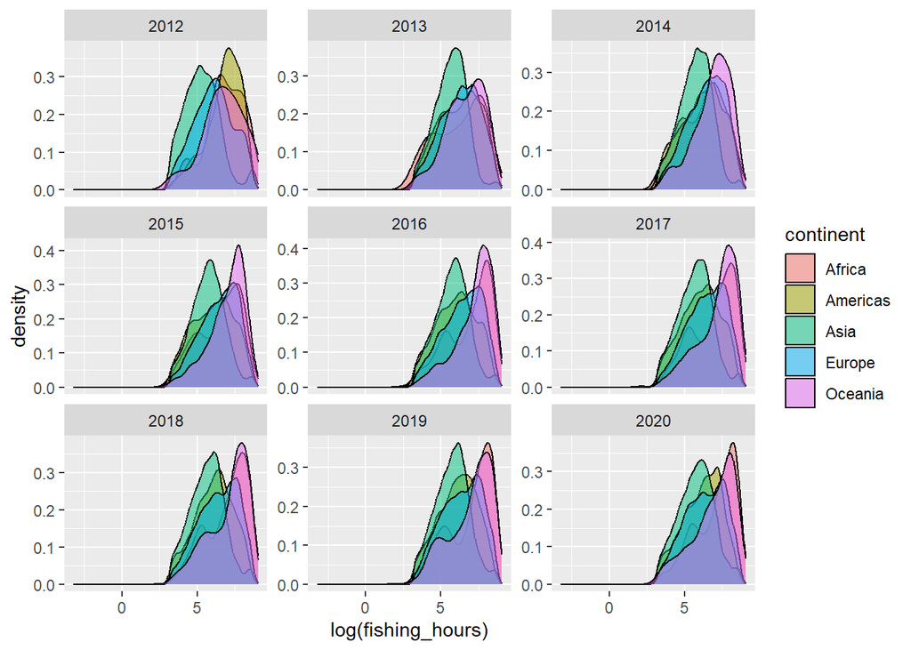

```r
tidy_data_vessels  %>%
  ggplot(aes(x=log(fishing_hours))) +
  geom_density(aes(group=continent, fill=continent),alpha=0.5)+
  facet_wrap(~ year,scales = "free_y")
```

There are some apparent changes, but they are difficult to appreciate with these plots Let us change to `geom_boxplot()`

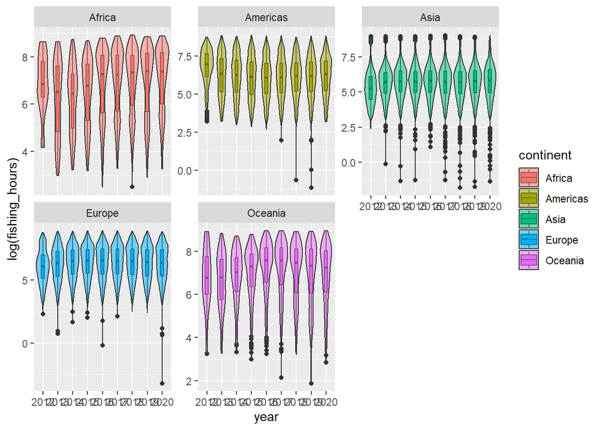

```r
tidy_data_vessels  %>%
  ggplot(aes(x=year)) +
  geom_boxplot(aes(y=log(fishing_hours),group=year, fill=continent), width=0.2)+
  geom_violin(aes(y=log(fishing_hours),group=year, fill=continent), alpha=.5)+
    facet_wrap(~ continent,scales = "free_y")
```

### Plots with three variables

### Heatmaps

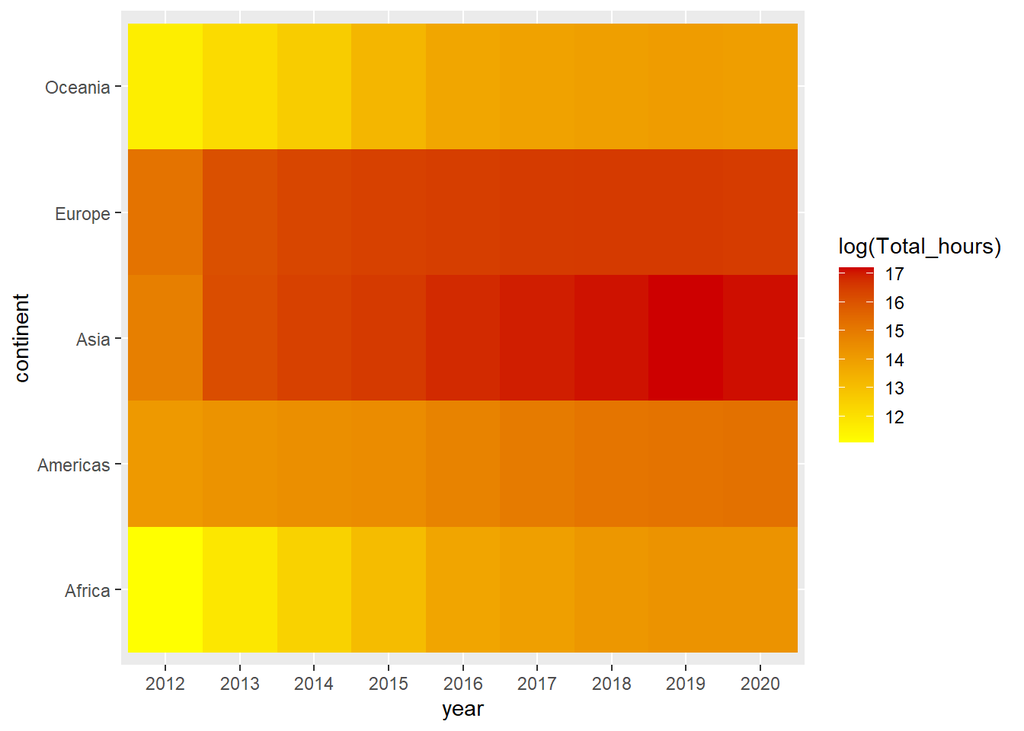

```r
tidy_data_vessels  %>% group_by(continent,year) %>%
  summarise(Total_hours=sum(fishing_hours)) %>%
  ggplot(aes(x=year,y=continent,fill=log(Total_hours))) +
  geom_tile() +
  scale_fill_gradient(low="yellow", high="red3")
```

### Bubbleplot

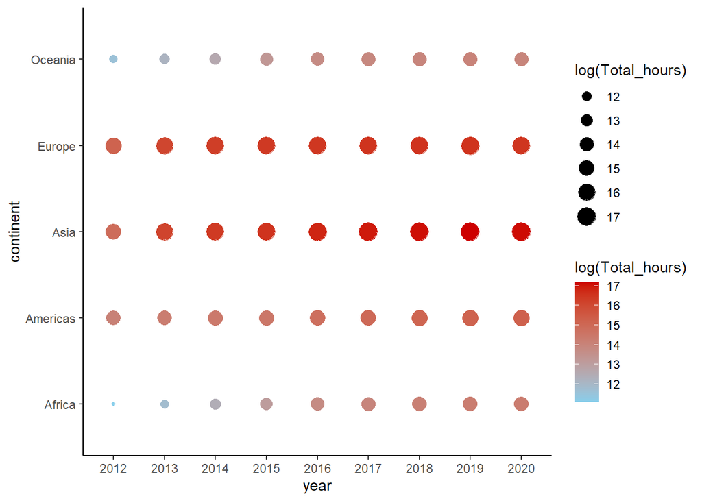

```r
tidy_data_vessels  %>% group_by(continent,year) %>%
  summarise(Total_hours=sum(fishing_hours)) %>%
  ggplot(aes(x=year,y=continent)) +
  geom_point(aes(size=log(Total_hours),color=log(Total_hours))) +
  scale_color_gradient(low="skyblue", high="red3") +
  theme_classic()
```

### Cumulative areas over time

### Cummulative area plot

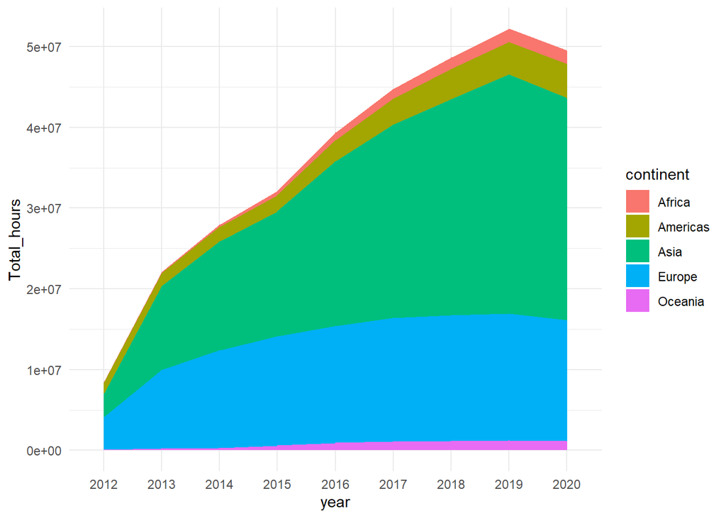

```r
tidy_data_vessels  %>% group_by(continent,year) %>%
  summarise(Total_hours=sum(fishing_hours)) %>%
  ggplot(aes(x=year,Total_hours)) +
  geom_area(aes(group=continent,fill=continent)) +
  theme_minimal()
```